# Data Visualization In Basic R Graphics

With the base R package, we can produce various plots to visualize our data but, the charts are less pleasing and we have to write complex R-codes too.

So, for data visualization purpose, we mostly use the *“ggplot2”* package, that has sophisticated graphics.

Still, let’s see how we can generate some simple charts using the basic R graphics.

### Scatter Plot

Here is an example of a basic scatter plot in R :

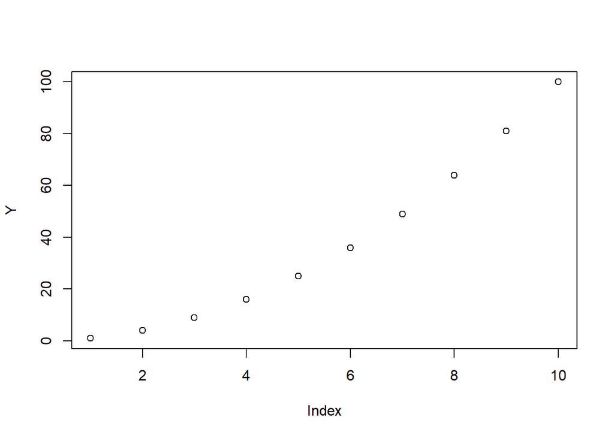

```r
X = 1:10
Y = X^2

plot(Y)
```

#### Analysing The *mtcars* Dataset

- *mtcars* is a dataframe with 32 observations on 11 variables and comes with the base-R package.
- The data was extracted from the *1974-Motor Trend US Magazine*, and comprises fuel consumption and 10 aspects of automobile design and performance for 32 automobiles(1973-74 models).

Let’s have a summary view of *mtcars* dataset before plotting any chart :

```r
summary(mtcars)
```

```
##       mpg             cyl             disp             hp
##  Min.   :10.40   Min.   :4.000   Min.   : 71.1   Min.   : 52.0
##  1st Qu.:15.43   1st Qu.:4.000   1st Qu.:120.8   1st Qu.: 96.5
##  Median :19.20   Median :6.000   Median :196.3   Median :123.0
##  Mean   :20.09   Mean   :6.188   Mean   :230.7   Mean   :146.7
##  3rd Qu.:22.80   3rd Qu.:8.000   3rd Qu.:326.0   3rd Qu.:180.0
##  Max.   :33.90   Max.   :8.000   Max.   :472.0   Max.   :335.0
##       drat             wt             qsec             vs
##  Min.   :2.760   Min.   :1.513   Min.   :14.50   Min.   :0.0000
##  1st Qu.:3.080   1st Qu.:2.581   1st Qu.:16.89   1st Qu.:0.0000
##  Median :3.695   Median :3.325   Median :17.71   Median :0.0000
##  Mean   :3.597   Mean   :3.217   Mean   :17.85   Mean   :0.4375
##  3rd Qu.:3.920   3rd Qu.:3.610   3rd Qu.:18.90   3rd Qu.:1.0000
##  Max.   :4.930   Max.   :5.424   Max.   :22.90   Max.   :1.0000
##        am              gear            carb
##  Min.   :0.0000   Min.   :3.000   Min.   :1.000
##  1st Qu.:0.0000   1st Qu.:3.000   1st Qu.:2.000
##  Median :0.0000   Median :4.000   Median :2.000
##  Mean   :0.4062   Mean   :3.688   Mean   :2.812
##  3rd Qu.:1.0000   3rd Qu.:4.000   3rd Qu.:4.000
##  Max.   :1.0000   Max.   :5.000   Max.   :8.000
```

Now, let’s see a corelation between the `wt` (Car Weight) & `mpg` (Miles Per Gallon) :

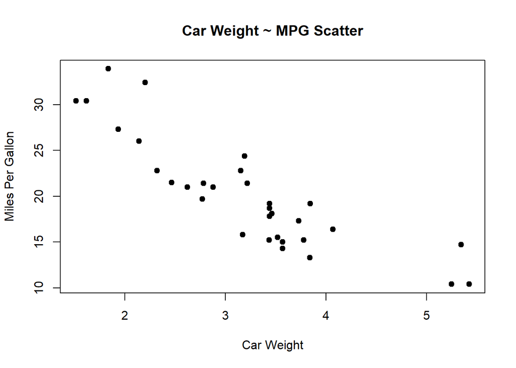

```r
attach(mtcars)

plot(wt,mpg,
     main = "Car Weight ~ MPG Scatter",
     xlab = "Car Weight",
     ylab = "Miles Per Gallon",
     pch = 19)
```

### Line Plot

Here is an example of a basic line plot in R :

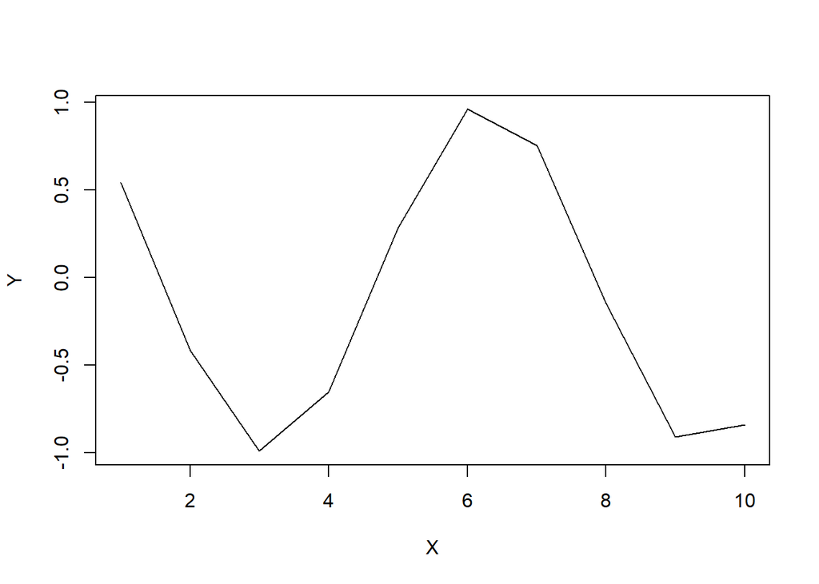

```r
X = 1:10
Y = cos(X)

plot(X,Y,
     type = "l")
```

### Bar Plot

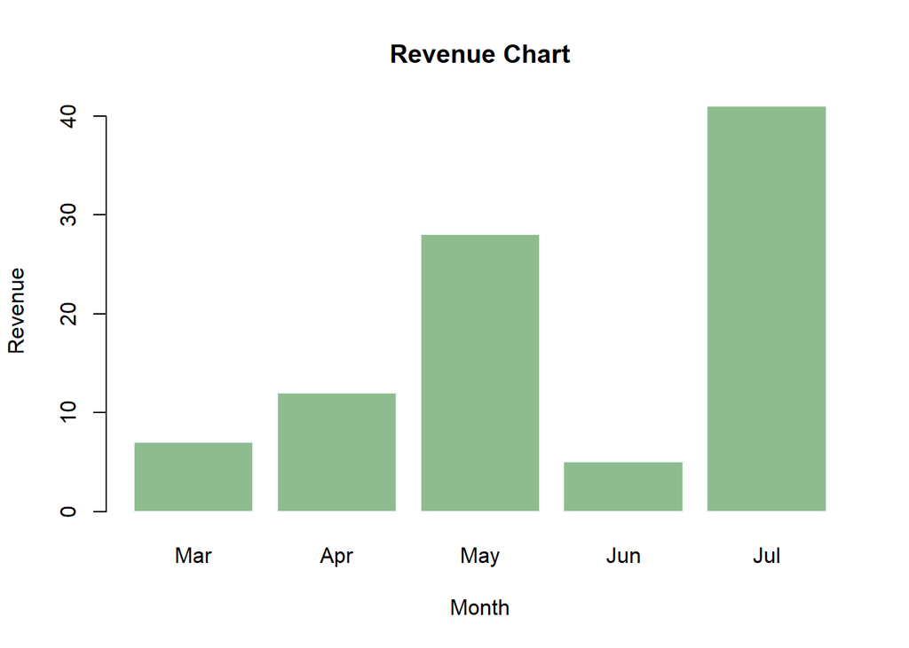

```r
H = c(7, 12, 28, 5, 41)

M = c("Mar", "Apr", "May", "Jun", "Jul")

barplot(H, names.arg = M,
        xlab = "Month",
        ylab = "Revenue",
        main = "Revenue Chart",
        col = "darkseagreen",
        border = "aliceblue"
        )
```